# Reproducible Research-Course Project

#### This assignment makes use of data from a personal activity monitoring device. This device collects data at 5 minute intervals through out the day. The data consists of two months of data from an anonymous individual collected during the months of October and November, 2012 and include the number of steps taken in 5 minute intervals each day.

```r
# install.packages("lattice")
# install.packages("knitr")
library(knitr)
```

```r
library(ggplot2)
library(lattice)
```

### Loading and preprocessing the data

```r
activityData <- read.csv ("C:/Users/lsharifi/Desktop/Rot2/coursera/A5-W2-Courseproject/activity.csv", header = T, sep = ",", stringsAsFactors = F)
```

### convert the date column to the appropriate format:

```r
activityData$date <- as.Date(activityData$date, "%Y-%m-%d")
str(activityData)
```

```
## 'data.frame':    17568 obs. of  3 variables:
##  $ steps   : int  NA NA NA NA NA NA NA NA NA NA ...
##  $ date    : Date, format: "2012-10-01" "2012-10-01" ...
##  $ interval: int  0 5 10 15 20 25 30 35 40 45 ...
```

## 1- What is mean total number of steps taken per day?

### Create a histogram of the total number of steps taken each day

```r
totalSteps <- aggregate(steps ~ date, data = activityData, sum, na.rm = TRUE)
str(totalSteps)
```

```
## 'data.frame':    53 obs. of  2 variables:
##  $ date : Date, format: "2012-10-02" "2012-10-03" ...
##  $ steps: int  126 11352 12116 13294 15420 11015 12811 9900 10304 17382 ...
```

```r
colnames(totalSteps)<-c("date","steps")
head(totalSteps)
```

```
##         date steps
## 1 2012-10-02   126
## 2 2012-10-03 11352
## 3 2012-10-04 12116
## 4 2012-10-05 13294
## 5 2012-10-06 15420
## 6 2012-10-07 11015
```

### Calculate and report the mean and median total number of steps taken per day

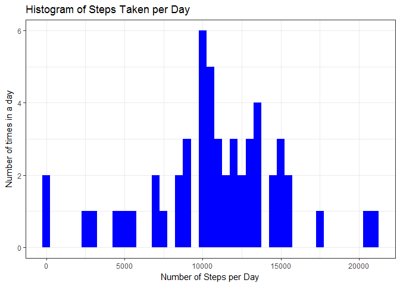

```r
mean_steps <- mean(totalSteps$steps,na.rm=TRUE)

median_steps <- median(totalSteps$steps,na.rm=TRUE)

ggplot(totalSteps, aes(x = steps)) +
                      geom_histogram(fill = "blue", binwidth = 500) +
                                                 labs(title="Histogram of Steps Taken per Day",
                                                                 x = "Number of Steps per Day", y = "Number of times in a day") + theme_bw()
```

```r
dev.copy(png,'C:/Users/lsharifi/Desktop/Rot2/coursera/A5-W2-Courseproject/plot1.png')
```

```r
dev.off()
```

#### The mean total number of steps taken per day is 1.0766 × 10^4 steps

#### The median total number of steps taken per day is 10765 steps

## 2- What is the average daily activity pattern?

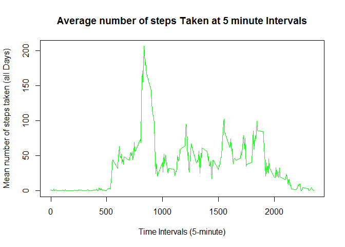

```r
steps_interval <- aggregate(steps ~ interval, data =activityData, mean, na.rm = TRUE)
plot(steps ~ interval, data = steps_interval, type = "l", xlab = "Time Intervals (5-minute)",
     ylab = "Mean number of steps taken (all Days)", main = "Average number of steps Taken at 5 minute Intervals",  col = "green")
```

```r
png("C:/Users/lsharifi/Desktop/Rot2/coursera/A5-W2-Courseproject/plot2.png")

dev.off()
```

```r
max_interval <- steps_interval[which.max( steps_interval$steps),]
```